# DAB 502 : LAB 2

## Pallavi Ravikumar Menon

### I. Load packages

```r
library(tidyverse)
library(here)
library(ggplot2)
library(gridExtra)
```

### 2. Read Data

```r
ames <- read_csv(here('data', 'ames.csv'))
```

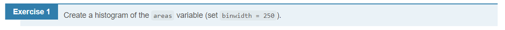

```r
area <- ames$area
price <- ames$price

summary(area)
```

```
##    Min. 1st Qu.  Median    Mean 3rd Qu.    Max.
##     334    1126    1442    1500    1743    5642
```

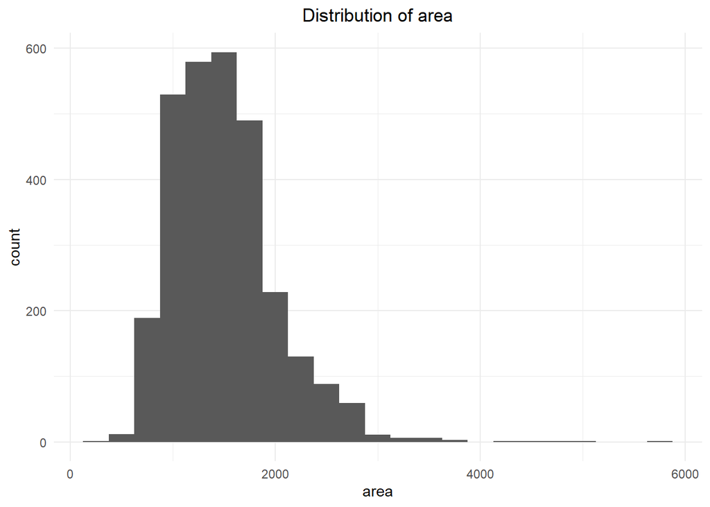

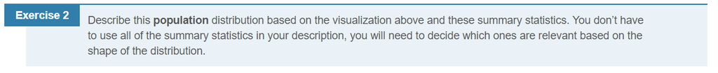

```r
plot1 <- ggplot(ames, aes(area)) + geom_histogram(binwidth=250) +
         ggtitle("Distribution of area") + theme_minimal() + theme(plot.title = element_text (hjust = 0.5))
plot1
```

```r
ames %>%
  summarize(mu = mean(area), pop_med = median(area),
            sigma = sd(area), pop_iqr = IQR(area),
            pop_min = min(area), pop_max = max(area),
            pop_q1 = quantile(area, 0.25),  # first quartile, 25th percentile
            pop_q3 = quantile(area, 0.75))  # third quartile, 75th percentile
```

```
## # A tibble: 1 x 8
##      mu pop_med sigma pop_iqr pop_min pop_max pop_q1 pop_q3
##   <dbl>   <dbl> <dbl>   <dbl>   <dbl>   <dbl>  <dbl>  <dbl>
## 1 1500.    1442  506.    617.     334    5642   1126  1743.
```

**1) The distribution is right skewed.**  
**2) The relevant summary staistics are;**  
**Mean = 1500**  
**Median = 1442**  
**Min = 334**  
**Max= 5642**

## The unknown sampling distribution

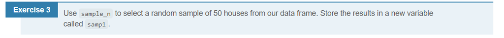

```r
samp1 <- sample_n(ames,50)
```

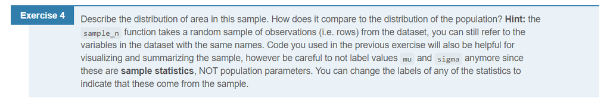

```r
samp1 %>%
  summarize(samp_mean = mean(area), samp_med = median(area),
            samp_iqr = IQR(area),
            samp_min = min(area), samp_max = max(area),
            samp_q1 = quantile(area, 0.25),
            samp_q3 = quantile(area, 0.75))
```

```
## # A tibble: 1 x 7
##   samp_mean samp_med samp_iqr samp_min samp_max samp_q1 samp_q3
##       <dbl>    <dbl>    <dbl>    <dbl>    <dbl>   <dbl>   <dbl>
## 1     1523.    1488.     499.      672     2599   1184.   1682.
```

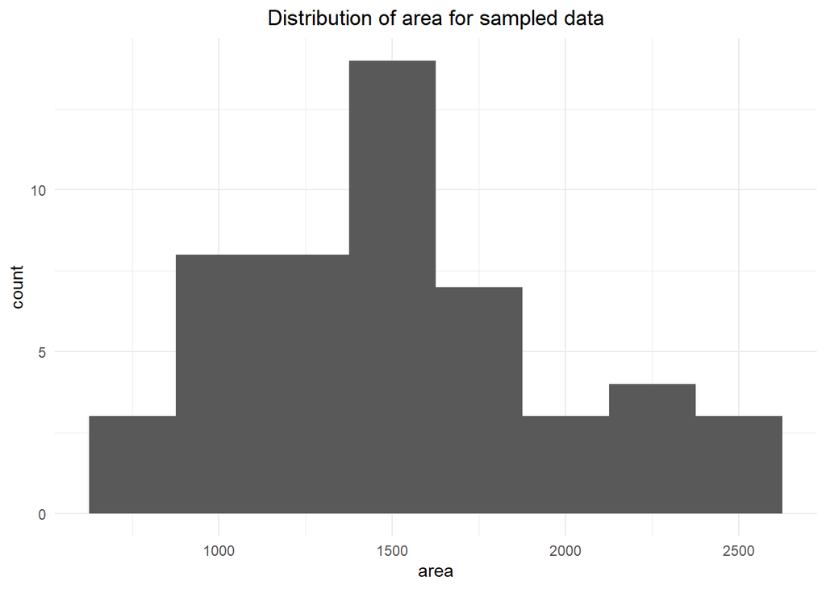

```r
plot2 <- ggplot(samp1, aes(area)) + geom_histogram(binwidth=250) +
         ggtitle("Distribution of area for sampled data") + theme_minimal() + theme(plot.title = element_text (hjust = 0.5))
plot2
```

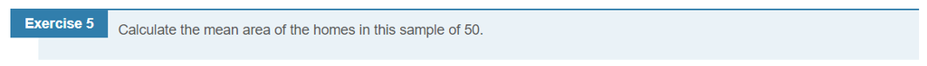

```r
x <- mean(samp1$area)
sprintf("%f is the mean area of the homes in this sample of 50. ", x)
```

```
## [1] "1523.160000 is the mean area of the homes in this sample of 50. "
```

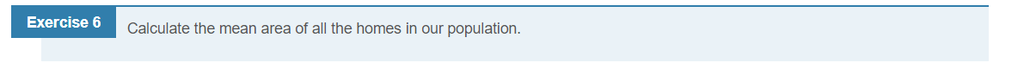

```r
y <- mean(ames$area)
sprintf("%f  is the mean area of all the homes in our population. ", y)
```

```
## [1] "1499.690444  is the mean area of all the homes in our population. "
```

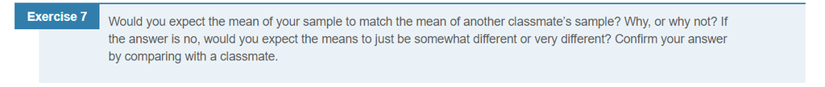

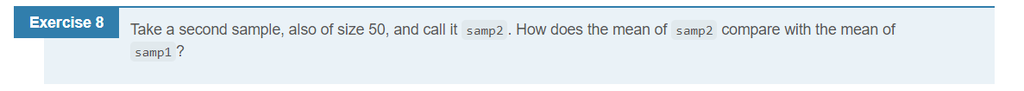

```r
samp2 <- sample_n(ames,50)
z <- mean(samp2$area)
sprintf("%f  is the mean area of all the homes in sample 2. ", z)
```

```
## [1] "1590.280000  is the mean area of all the homes in sample 2. "
```

**Compared to mean of sample 1, the mean fo sample 2 is greater than sample 1**

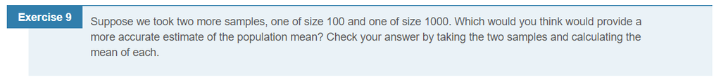

```r
samp100 <- sample_n(ames,100)

samp1000 <- sample_n(ames,1000)

a <- mean(samp100$area)
b <- mean(samp1000$area)

sprintf("%f  is the mean area of all the homes in sample 100 ", a)
```

```
## [1] "1483.190000  is the mean area of all the homes in sample 100 "
```

```r
sprintf("%f  is the mean area of all the homes in sample 1000. ", b)
```

```
## [1] "1477.738000  is the mean area of all the homes in sample 1000. "
```

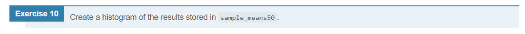

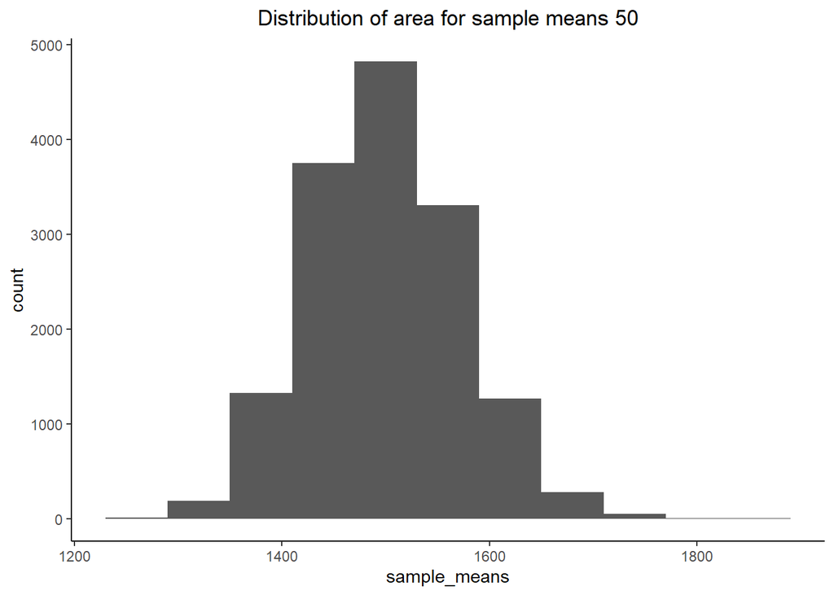

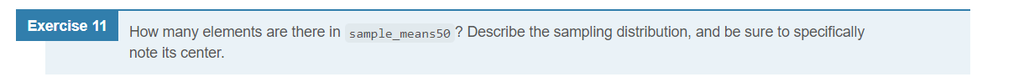

```r
sample_means50 <- tibble(sample_means =
                           replicate(15000,
                                     mean(sample(ames$area, 50,replace = TRUE))))

plot3 <- ggplot(sample_means50, aes(sample_means)) + geom_histogram(binwidth=60) +
         ggtitle("Distribution of area for sample means 50") + theme_classic() + theme(plot.title = element_text (hjust = 0.5))
plot3
```

How many elements are there in sample_means50? Describe the sampling distribution, and be sure to specifically note its center.

**There are 15000 observations in sample_means50.**

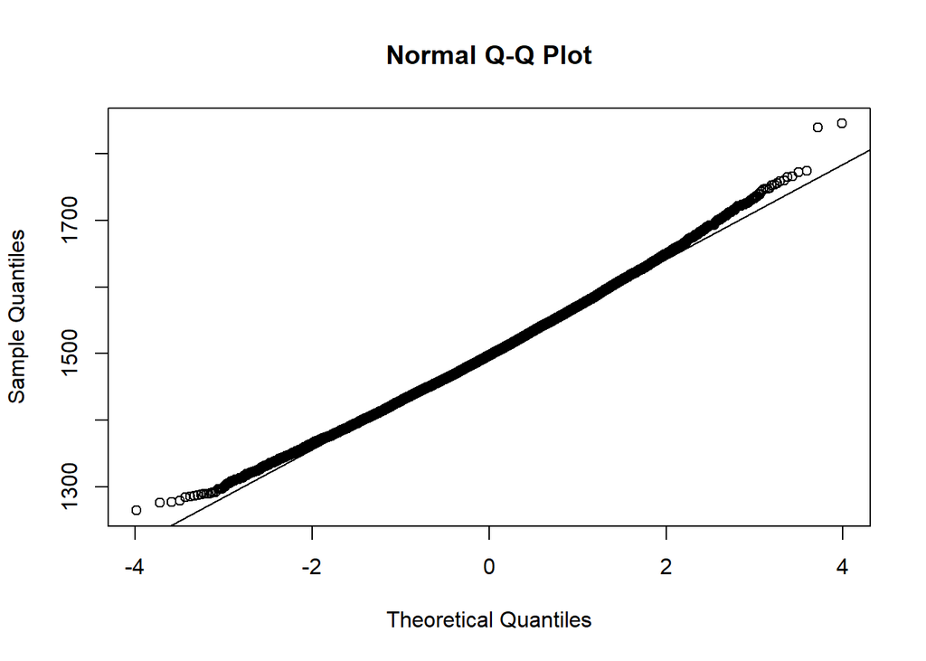

```r
qqnorm(sample_means50$sample_means)
qqline(sample_means50)
```

**The sampling distribution is almost perfectly normal as can be seen on the qqplot below.**

## Interlude : sampling distribution

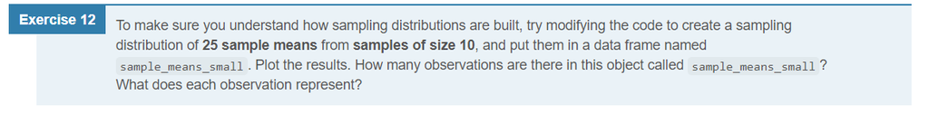

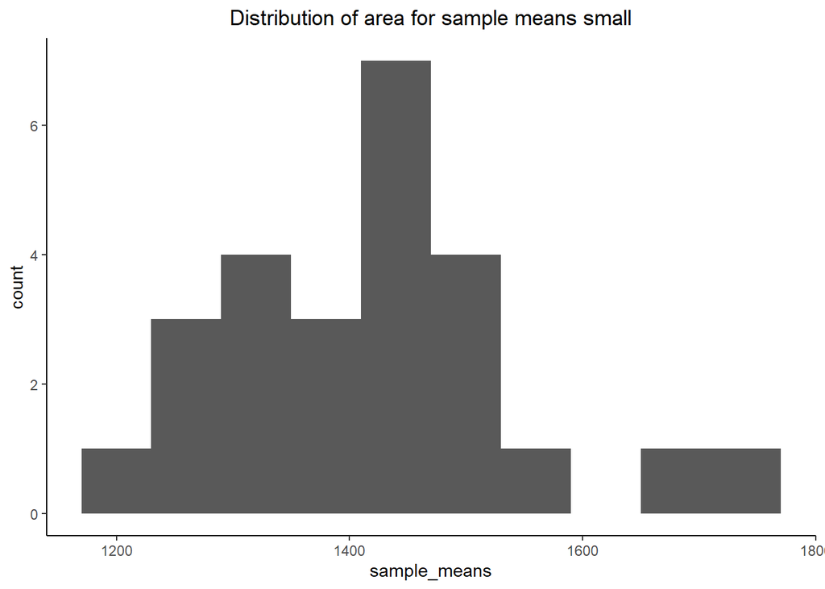

```r
sample_means_small <- tibble(sample_means =
                           replicate(25,
                                     mean(sample(ames$area, 10,replace = TRUE))))

plot4 <- ggplot(sample_means_small, aes(sample_means)) + geom_histogram(binwidth=60) +
         ggtitle("Distribution of area for sample means small") + theme_classic() + theme(plot.title = element_text (hjust = 0.5))
plot4
```

**Each observation in the variable sample_means small represents the mean area for of a random sample from the main dataset.**

## Sample size and sampling distribution

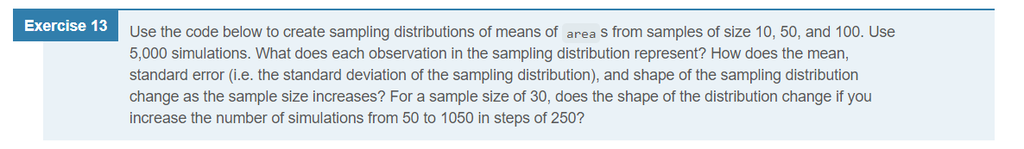

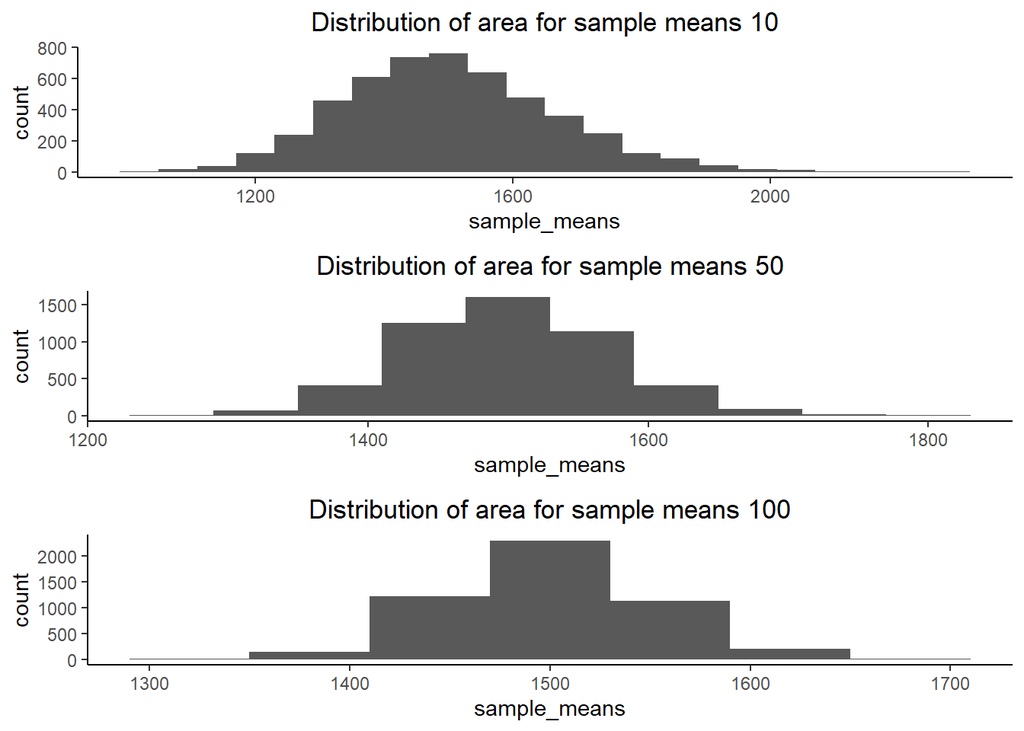

```r
sample_means_10 <- tibble(sample_means =
                           replicate(5000,
                                     mean(sample(ames$area,10,replace = TRUE))))
sample_means_50 <- tibble(sample_means =
                           replicate(5000,
                                     mean(sample(ames$area,50,replace = TRUE))))
sample_means_100 <- tibble(sample_means =
                           replicate(5000,
                                     mean(sample(ames$area,100,replace = TRUE))))

plot5 <- ggplot(sample_means_10, aes(sample_means)) + geom_histogram(binwidth=60) +
         ggtitle("Distribution of area for sample means 10") + theme_classic() + theme(plot.title = element_text (hjust = 0.5))

plot6 <- ggplot(sample_means_50, aes(sample_means)) + geom_histogram(binwidth=60) +
         ggtitle("Distribution of area for sample means 50") + theme_classic() + theme(plot.title = element_text (hjust = 0.5))

plot7 <- ggplot(sample_means_100, aes(sample_means)) + geom_histogram(binwidth=60) +
         ggtitle("Distribution of area for sample means 100") + theme_classic() + theme(plot.title = element_text (hjust = 0.5))


grid.arrange(plot5, plot6, plot7)
```

**The plots for sample size of 10, 50 and 100 can be seen. We can obseve that with an increase in size of sample size the spread of the data is reduced and it gets closer to the true population mean.**

## More Practice

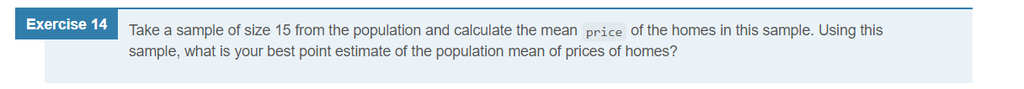

```r
samp_price <- sample_n(ames,15)

q <- mean(samp_price$price)
sprintf("%f is the best point estimate of the population mean of prices of homes ", q)
```

```
## [1] "193300.000000 is the best point estimate of the population mean of prices of homes "
```

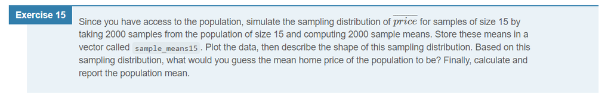

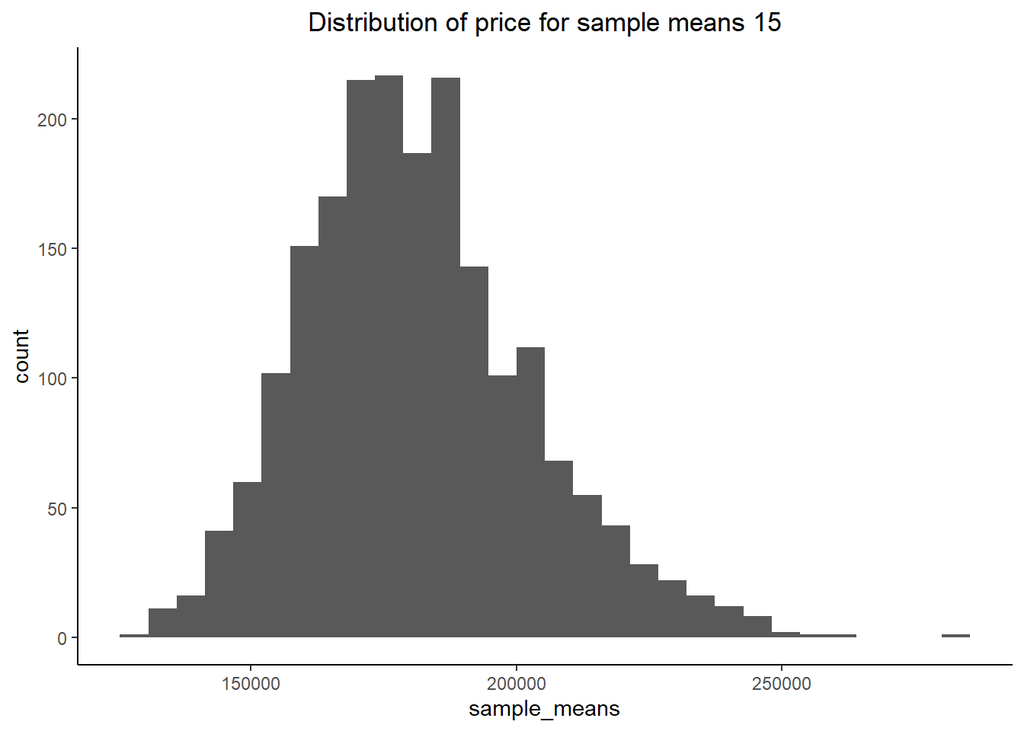

```r
sample_means15 <- tibble(sample_means =
                           replicate(2000,
                                     mean(sample(ames$price,15,replace = TRUE))))

plot8 <- ggplot(sample_means15, aes(sample_means)) + geom_histogram() +
         ggtitle("Distribution of price for sample means 15") + theme_classic() + theme(plot.title = element_text (hjust = 0.5))
plot8
```

**The distribution is unimodal and right skewed.**

```r
d <- mean(sample_means15$sample_means)
e <- mean(price)

sprintf("%f  estimated mean home price of the population for sample size 15 ", d)
```

```
## [1] "181303.127400  estimated mean home price of the population for sample size 15 "
```

```r
sprintf("%f  actual mean home price of the population. ",e)
```

```
## [1] "180796.060068  actual mean home price of the population. "
```

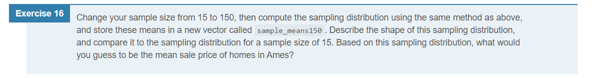

[figure not shown]

```r
sample_means150 <- tibble(sample_means =
                           replicate(2000,
                                     mean(sample(ames$price,150,replace = TRUE))))

plot9 <- ggplot(sample_means150, aes(sample_means)) + geom_histogram() +
         ggtitle("Distribution of price for sample means 15") + theme_classic() + theme(plot.title = element_text (hjust = 0.5))
plot9
```

```r
f <- mean(sample_means150$sample_means)
g <- mean(price)

sprintf("%f  estimated mean home price of the population for sample size 150 ", f)
```

```
## [1] "180803.409953  estimated mean home price of the population for sample size 150 "
```

```r
sprintf("%f  actual mean home price of the population. ",g)
```

```
## [1] "180796.060068  actual mean home price of the population. "
```

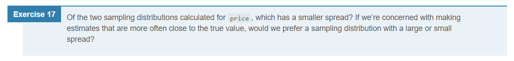

**1) Comparing the distribution for price for both the sampling size, it is clearly seen the spread for sampling size 150 is smaller.**  
**2) Also looking at the estimated price means for both distribution we can easily determine that increasing the sample size is more preferred as it estimates closely to the true mean value.**